# Foreigners, Migrants - OECD and UN data

2024/01/24

## R Markdown Options

- R Notebook: options
- isoslides_presentation:
- widescreen: yes
- smaller: yes
- pdf_documents: tinytex
- word_document:
- reference_doc: ref-doc-style.docx
- powerpoint_presentation:
- reference_doc: ref-ppt-style.pptx

## Abstract

> In this note, we study immigrants using OECD data and migrants using UN data. We also combine these two sets of data to provide examples to use public data.

## OECD data

### OECD data top

OECD data https://data.oecd.org/

- Browse by Topics (Choose from 12 topics) or Country (Choose from 37 countries)
- Topics:
  - Society
    - Demography
    - Inequality
    - Migration
    - Population by Region
    - Social protection

### Topic: Society - Migration

- Permanent immigrant inflows
  - Permanent immigrant inflows cover regulated movements of foreigners considered to be settling in the country from the perspective of the destination country. They cover regulated movements of foreigners as well as free movement migration. The data presented are the result of a standardisation process that allows for cross-country comparisons. This indicator is measured by numbers of permanent inflows.
- Stocks of foreign-born population in OECD countries
- Foreign-born population
- Foreign population
- Native-born employment
- Foreign-born employment
- Native-born unemployment
- Foreign-born unemployment
- Native-born participation rates
- Foreign-born participation rates

### Permanent immigrant inflows

Permanent immigrant inflows Total, Number, 2022 [Link](https://data.oecd.org/migration/permanent-immigrant-inflows.htm)

Definition of Permanent immigrant inflows

- Permanent immigrant inflows cover regulated movements of foreigners considered to be settling in the country from the perspective of the destination country. They cover regulated movements of foreigners as well as free movement migration. The data presented are the result of a standardisation process that allows for cross-country comparisons. This indicator is measured by numbers of permanent inflows.
- Citation: OECD (2024), Permanent immigrant inflows (indicator). doi: 10.1787/304546b6-en (Accessed on 27 January 2024)

### OECD: Permanent immigrant inflows

#### Data Information

- Data Site: https://data.oecd.org/migration/permanent-immigrant-inflows.htm
- Definition of Permanent immigrant inflows: Permanent immigrant inflows cover regulated movements of foreigners considered to be settling in the country from the perspective of the destination country. They cover regulated movements of foreigners as well as free movement migration. The data presented are the result of a standardisation process that allows for cross-country comparisons. This indicator is measured by numbers of permanent inflows.
- Citation: OECD (2024), Permanent immigrant inflows (indicator). doi: 10.1787/304546b6-en (Accessed on 28 January 2024)
- Categories: Total, Work, Free movements, Family, Family accompanying workers, Humanitarian, Other

Read the downloaded full data of ‘Permanent Immigrant Inflows’.

```r
df_inflows <- read_csv("data/DP_LIVE_28012024004117279.csv")
df_inflows |> slice_head(n = 10)
```

```
## # A tibble: 10 × 8
##    LOCATION INDICATOR   SUBJECT MEASURE FREQUENCY  TIME Value `Flag Codes`
##    <chr>    <chr>       <chr>   <chr>   <chr>     <dbl> <dbl> <lgl>
##  1 AUS      IMMIGINFLOW FAM     NBR     A          2003 40105 NA
##  2 AUS      IMMIGINFLOW FAM     NBR     A          2004 42187 NA
##  3 AUS      IMMIGINFLOW FAM     NBR     A          2005 43747 NA
##  4 AUS      IMMIGINFLOW FAM     NBR     A          2006 45943 NA
##  5 AUS      IMMIGINFLOW FAM     NBR     A          2007 48769 NA
##  6 AUS      IMMIGINFLOW FAM     NBR     A          2008 49870 NA
##  7 AUS      IMMIGINFLOW FAM     NBR     A          2009 56366 NA
##  8 AUS      IMMIGINFLOW FAM     NBR     A          2010 60254 NA
##  9 AUS      IMMIGINFLOW FAM     NBR     A          2011 54543 NA
## 10 AUS      IMMIGINFLOW FAM     NBR     A          2012 58604 NA
```

### Categorial Variables

```r
df_inflows |> select(-Value, -LOCATION, -TIME) |> lapply(unique)
```

```
## $INDICATOR
## [1] "IMMIGINFLOW"
##
## $SUBJECT
## [1] "FAM"      "FAMWORKR" "FREEMOVS" "HUMNTRN"  "OTH"      "WORK"     "TOT"
##
## $MEASURE
## [1] "NBR"
##
## $FREQUENCY
## [1] "A"
##
## $`Flag Codes`
## [1] NA
```

Add country names using the `countrycode` package and delete INDICATOR, MEASURE, FREQUENCY, Flag Codes.

```r
df_in <- df_inflows |>
  mutate(country = countrycode(LOCATION, "iso3c", "country.name"),
         .before = LOCATION) |>
  select(country, iso3c = LOCATION, category = SUBJECT,
         year = TIME, value = Value)
df_in |> head()
```

```
## # A tibble: 6 × 5
##   country   iso3c category  year value
##   <chr>     <chr> <chr>    <dbl> <dbl>
## 1 Australia AUS   FAM       2003 40105
## 2 Australia AUS   FAM       2004 42187
## 3 Australia AUS   FAM       2005 43747
## 4 Australia AUS   FAM       2006 45943
## 5 Australia AUS   FAM       2007 48769
## 6 Australia AUS   FAM       2008 49870
```

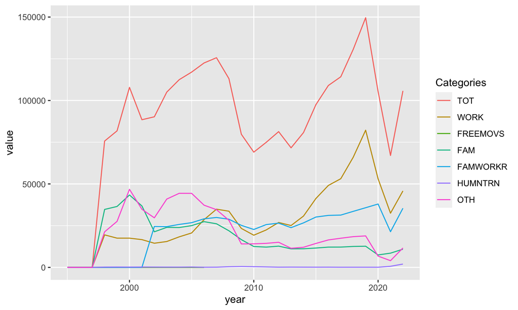

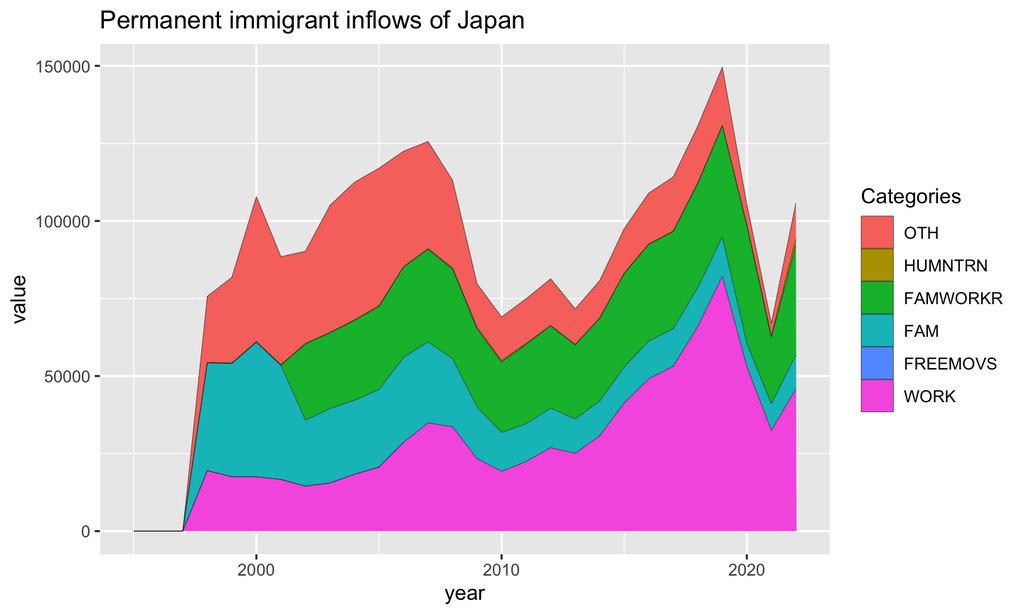

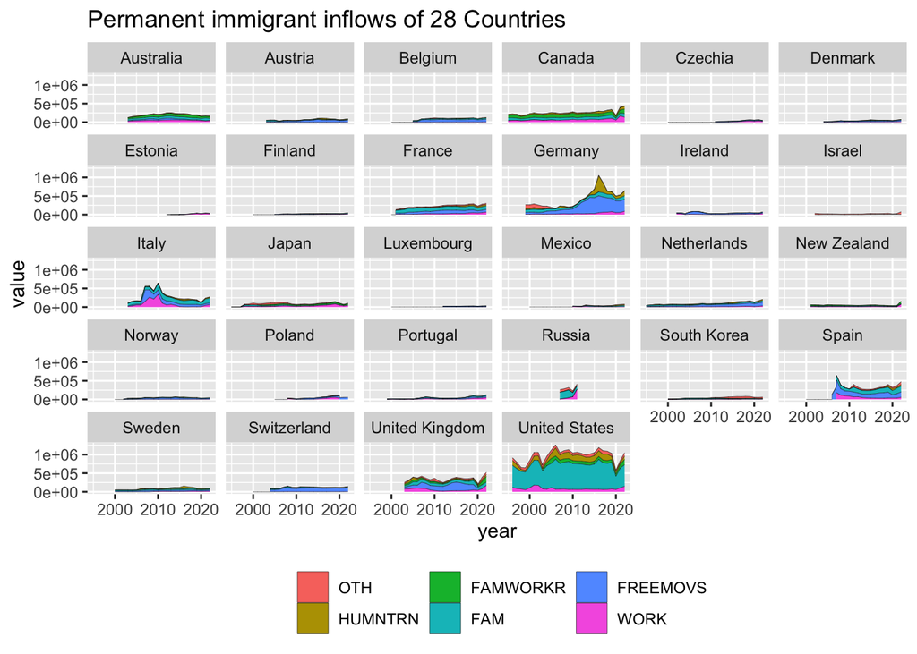

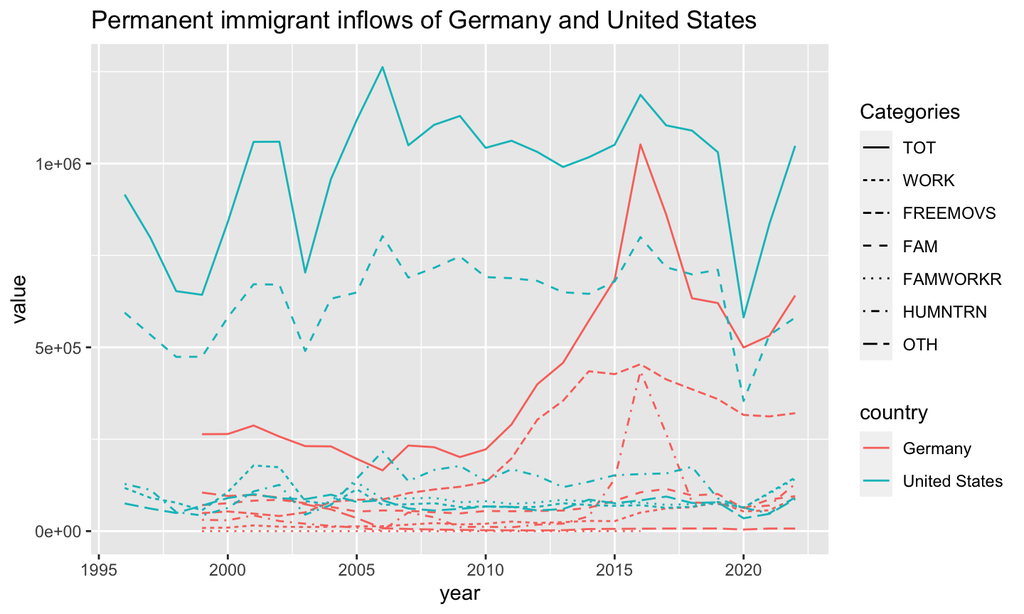

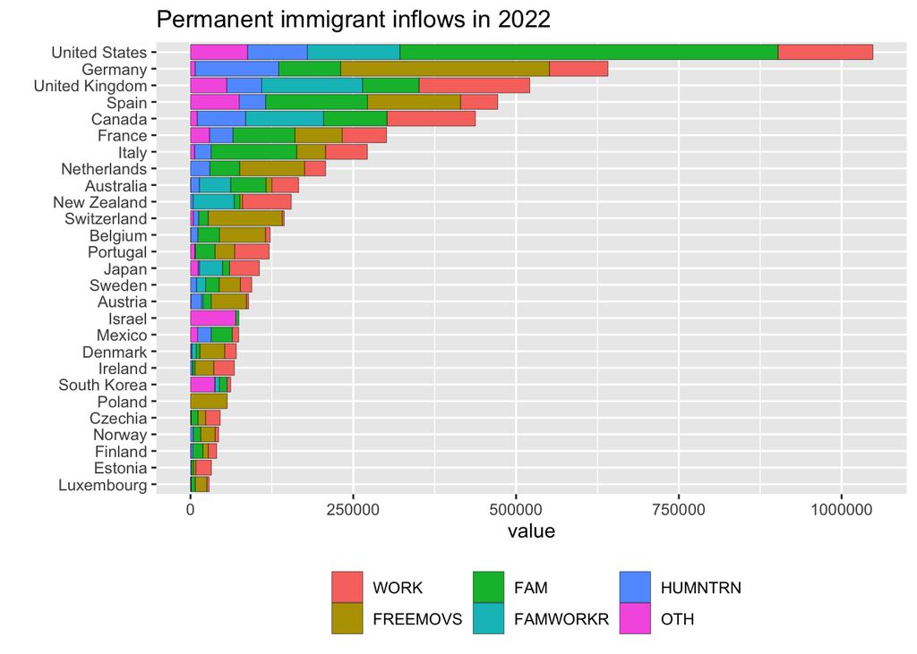